# **SuperKart Sales Prediction**

### **Store Data Analysis - Deep Dive** - Not complete yet, can be expanded

Let's look at the effect on various store characteristics versus the Product_MRP to get some insight into the tyoes of stores we are dealing with

```python
data.groupby(['Store_Id'])['Product_Store_Sales_Total'].sum()
```

| Store_Id | Product_Store_Sales_Total |
| --- | --- |
| OUT001 | 6223113.18 |
| OUT002 | 2030909.72 |
| OUT003 | 6673457.57 |
| OUT004 | 15427583.43 |

**dtype:** float64

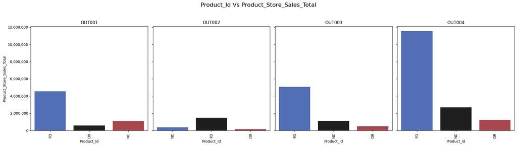

```
/n
/n
```

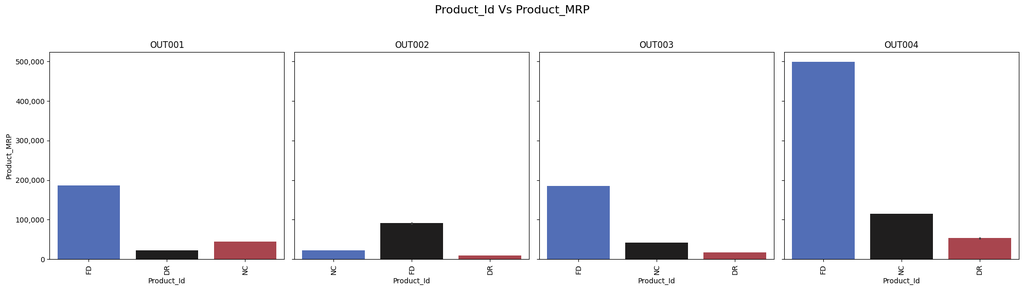

```python
# Function to format the y-axis labels as plain numbers
def format_yaxis(x, pos):
    return f'{int(x):,}'

# Create a subplot grid with 1 row and 4 columns, sharing the y-axis
fig, axes = plt.subplots(nrows=1, ncols=4, figsize=(20, 6), sharey=True)

# Add a main title for the entire figure
fig.suptitle('Product_Id Vs Product_Store_Sales_Total', fontsize=16)

# Iterate through stores and create a plot for each
for i, store_id in enumerate(['OUT001', 'OUT002', 'OUT003', 'OUT004']):
    # Plot the barplot on the corresponding axes
    sns.barplot(data=data[data['Store_Id'] == store_id], x='Product_Id',  y='Product_Store_Sales_Total',
                estimator=np.sum, ci=1, palette='icefire', ax=axes[i])

    # Set the title for each subplot
    axes[i].tick_params(axis='x', rotation=90)
    axes[i].set_title(f"{store_id}")

    # Apply the y-axis formatting to avoid exponents
    axes[i].yaxis.set_major_formatter(FuncFormatter(format_yaxis))

# Adjust the layout to prevent overlap
plt.tight_layout(rect=[0, 0.05, 1, 0.95])  # Adjust bottom and top margins to fit the suptitle and x-axis label

plt.show()

#
print('/n')
print('/n')
#

# Function to format the y-axis labels as plain numbers
def format_yaxis(x, pos):
    return f'{int(x):,}'

# Create a subplot grid with 1 row and 4 columns, sharing the y-axis
fig, axes = plt.subplots(nrows=1, ncols=4, figsize=(20, 6), sharey=True)

# Add a main title for the entire figure
fig.suptitle('Product_Id Vs Product_MRP', fontsize=16)

# Iterate through stores and create a plot for each
for i, store_id in enumerate(['OUT001', 'OUT002', 'OUT003', 'OUT004']):
    # Plot the barplot on the corresponding axes
    sns.barplot(data=data[data['Store_Id'] == store_id], x='Product_Id',  y='Product_MRP',
                estimator=np.sum, ci=1, palette='icefire', ax=axes[i])

    # Set the title for each subplot
    axes[i].tick_params(axis='x', rotation=90)
    axes[i].set_title(f"{store_id}")

    # Apply the y-axis formatting to avoid exponents
    axes[i].yaxis.set_major_formatter(FuncFormatter(format_yaxis))

# Adjust the layout to prevent overlap
plt.tight_layout(rect=[0, 0.05, 1, 0.95])  # Adjust bottom and top margins to fit the suptitle and x-axis label

plt.show()
```

**Observations:**

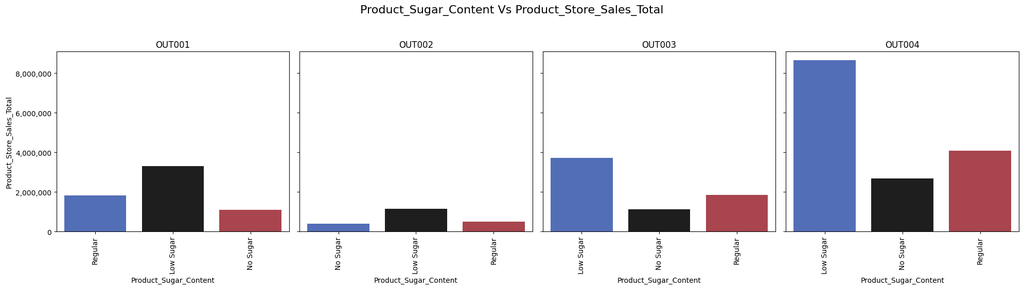

```
/n
/n
```

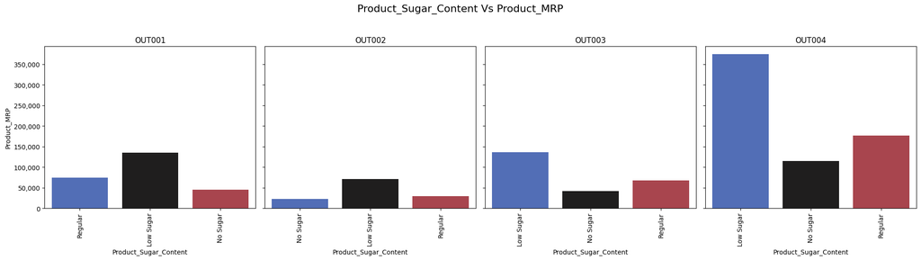

```python
# Function to format the y-axis labels as plain numbers
def format_yaxis(x, pos):
    return f'{int(x):,}'

# Create a subplot grid with 1 row and 4 columns, sharing the y-axis
fig, axes = plt.subplots(nrows=1, ncols=4, figsize=(20, 6), sharey=True)

# Add a main title for the entire figure
fig.suptitle('Product_Sugar_Content Vs Product_Store_Sales_Total', fontsize=16)

# Iterate through stores and create a plot for each
for i, store_id in enumerate(['OUT001', 'OUT002', 'OUT003', 'OUT004']):
    # Plot the barplot on the corresponding axes
    sns.barplot(data=data[data['Store_Id'] == store_id], x='Product_Sugar_Content', y='Product_Store_Sales_Total',
                estimator=np.sum, ci=1, palette='icefire', ax=axes[i])

    # Set the title for each subplot
    axes[i].tick_params(axis='x', rotation=90)
    axes[i].set_title(f"{store_id}")

    # Apply the y-axis formatting to avoid exponents
    axes[i].yaxis.set_major_formatter(FuncFormatter(format_yaxis))

# Adjust the layout to prevent overlap
plt.tight_layout(rect=[0, 0.05, 1, 0.95])  # Adjust bottom and top margins to fit the suptitle and x-axis label

plt.show()

#
print('/n')
print('/n')
#

# Function to format the y-axis labels as plain numbers
def format_yaxis(x, pos):
    return f'{int(x):,}'

# Create a subplot grid with 1 row and 4 columns, sharing the y-axis
fig, axes = plt.subplots(nrows=1, ncols=4, figsize=(20, 6), sharey=True)

# Add a main title for the entire figure
fig.suptitle('Product_Sugar_Content Vs Product_MRP', fontsize=16)

# Iterate through stores and create a plot for each
for i, store_id in enumerate(['OUT001', 'OUT002', 'OUT003', 'OUT004']):
    # Plot the barplot on the corresponding axes
    sns.barplot(data=data[data['Store_Id'] == store_id], x='Product_Sugar_Content',  y='Product_MRP',
                estimator=np.sum, ci=1, palette='icefire', ax=axes[i])

    # Set the title for each subplot
    axes[i].tick_params(axis='x', rotation=90)
    axes[i].set_title(f"{store_id}")

    # Apply the y-axis formatting to avoid exponents
    axes[i].yaxis.set_major_formatter(FuncFormatter(format_yaxis))

# Adjust the layout to prevent overlap
plt.tight_layout(rect=[0, 0.05, 1, 0.95])  # Adjust bottom and top margins to fit the suptitle and x-axis label

plt.show()
```

**Observations:**

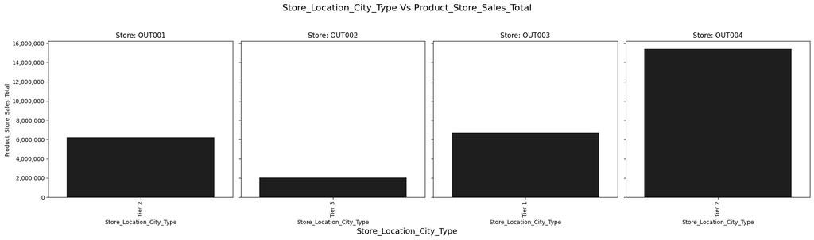

```
/n
/n
```

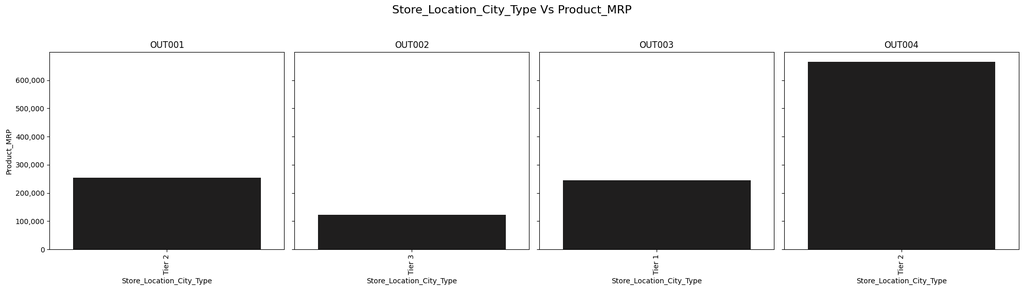

```python
# Function to format the y-axis labels as plain numbers
def format_yaxis(x, pos):
    return f'{int(x):,}'

# Create a subplot grid with 1 row and 4 columns, sharing the y-axis
fig, axes = plt.subplots(nrows=1, ncols=4, figsize=(20, 6), sharey=True)

# Add a main title for the entire figure
fig.suptitle('Store_Location_City_Type Vs Product_Store_Sales_Total', fontsize=16)

# Iterate through stores and create a plot for each
for i, store_id in enumerate(['OUT001', 'OUT002', 'OUT003', 'OUT004']):
    # Plot the barplot on the corresponding axes
    sns.barplot(data=data[data['Store_Id'] == store_id], x='Store_Location_City_Type', y='Product_Store_Sales_Total',
                estimator=np.sum, ci=1, palette='icefire', ax=axes[i])

    # Set the title for each subplot
    axes[i].tick_params(axis='x', rotation=90)
    axes[i].set_title(f"Store: {store_id}")

    # Apply the y-axis formatting to avoid exponents
    axes[i].yaxis.set_major_formatter(FuncFormatter(format_yaxis))

# Add a single x-axis title
fig.text(0.5, 0.04, 'Store_Location_City_Type', ha='center', fontsize=14)

# Adjust the layout to prevent overlap
plt.tight_layout(rect=[0, 0.05, 1, 0.95])  # Adjust bottom and top margins to fit the suptitle and x-axis label

plt.show()

#
print('/n')
print('/n')
#

# Function to format the y-axis labels as plain numbers
def format_yaxis(x, pos):
    return f'{int(x):,}'

# Create a subplot grid with 1 row and 4 columns, sharing the y-axis
fig, axes = plt.subplots(nrows=1, ncols=4, figsize=(20, 6), sharey=True)

# Add a main title for the entire figure
fig.suptitle('Store_Location_City_Type Vs Product_MRP', fontsize=16)

# Iterate through stores and create a plot for each
for i, store_id in enumerate(['OUT001', 'OUT002', 'OUT003', 'OUT004']):
    # Plot the barplot on the corresponding axes
    sns.barplot(data=data[data['Store_Id'] == store_id], x='Store_Location_City_Type',  y='Product_MRP',
                estimator=np.sum, ci=1, palette='icefire', ax=axes[i])

    # Set the title for each subplot
    axes[i].tick_params(axis='x', rotation=90)
    axes[i].set_title(f"{store_id}")

    # Apply the y-axis formatting to avoid exponents
    axes[i].yaxis.set_major_formatter(FuncFormatter(format_yaxis))

# Adjust the layout to prevent overlap
plt.tight_layout(rect=[0, 0.05, 1, 0.95])  # Adjust bottom and top margins to fit the suptitle and x-axis label

plt.show()
```

**Observations:**

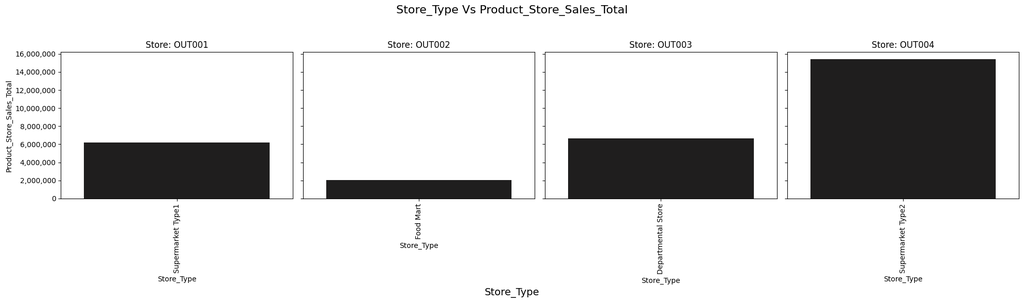

```
/n
/n
```

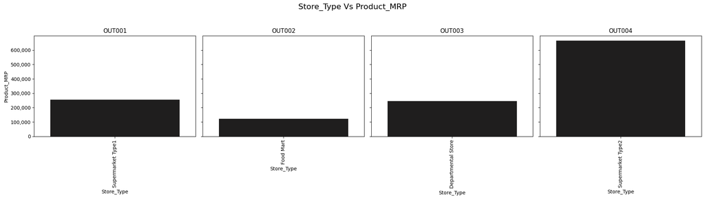

```python
# Function to format the y-axis labels as plain numbers
def format_yaxis(x, pos):
    return f'{int(x):,}'

# Create a subplot grid with 1 row and 4 columns, sharing the y-axis
fig, axes = plt.subplots(nrows=1, ncols=4, figsize=(20, 6), sharey=True)

# Add a main title for the entire figure
fig.suptitle('Store_Type Vs Product_Store_Sales_Total', fontsize=16)

# Iterate through stores and create a plot for each
for i, store_id in enumerate(['OUT001', 'OUT002', 'OUT003', 'OUT004']):
    # Plot the barplot on the corresponding axes
    sns.barplot(data=data[data['Store_Id'] == store_id], x='Store_Type', y='Product_Store_Sales_Total',
                estimator=np.sum, ci=1, palette='icefire', ax=axes[i])

    # Set the title for each subplot
    axes[i].tick_params(axis='x', rotation=90)
    axes[i].set_title(f"Store: {store_id}")

    # Apply the y-axis formatting to avoid exponents
    axes[i].yaxis.set_major_formatter(FuncFormatter(format_yaxis))

# Add a single x-axis title
fig.text(0.5, 0.04, 'Store_Type', ha='center', fontsize=14)

# Adjust the layout to prevent overlap
plt.tight_layout(rect=[0, 0.05, 1, 0.95])  # Adjust bottom and top margins to fit the suptitle and x-axis label

plt.show()

#
print('/n')
print('/n')
#

# Function to format the y-axis labels as plain numbers
def format_yaxis(x, pos):
    return f'{int(x):,}'

# Create a subplot grid with 1 row and 4 columns, sharing the y-axis
fig, axes = plt.subplots(nrows=1, ncols=4, figsize=(20, 6), sharey=True)

# Add a main title for the entire figure
fig.suptitle('Store_Type Vs Product_MRP', fontsize=16)

# Iterate through stores and create a plot for each
for i, store_id in enumerate(['OUT001', 'OUT002', 'OUT003', 'OUT004']):
    # Plot the barplot on the corresponding axes
    sns.barplot(data=data[data['Store_Id'] == store_id], x='Store_Type',  y='Product_MRP',
                estimator=np.sum, ci=1, palette='icefire', ax=axes[i])

    # Set the title for each subplot
    axes[i].tick_params(axis='x', rotation=90)
    axes[i].set_title(f"{store_id}")

    # Apply the y-axis formatting to avoid exponents
    axes[i].yaxis.set_major_formatter(FuncFormatter(format_yaxis))

# Adjust the layout to prevent overlap
plt.tight_layout(rect=[0, 0.05, 1, 0.95])  # Adjust bottom and top margins to fit the suptitle and x-axis label

plt.show()
```

**Observations:**

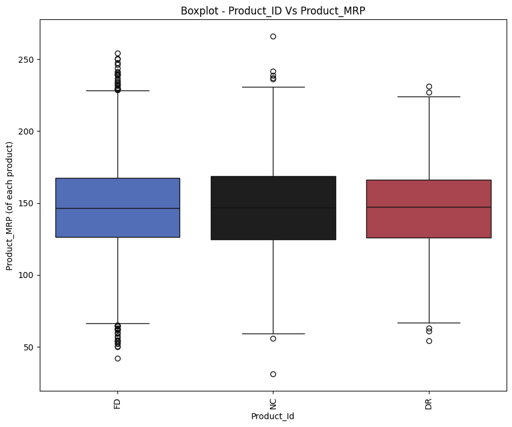

```python
# Visualize the effect of Product_Id on Product_Store_Sales_Total
plt.figure(figsize = [10, 8])
sns.boxplot(data = data, x = data.Product_Id, y = data.Product_MRP, palette = 'icefire')
plt.xticks(rotation = 90)
plt.title("Boxplot - Product_ID Vs Product_MRP")
plt.xlabel("Product_Id")
plt.ylabel("Product_MRP (of each product)")
plt.show()
```

**Observations:**

- The median of all MRP by Product_Id is roughly equal.

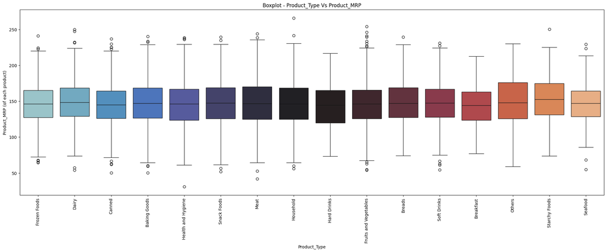

```python
# Visualize the effect of Product_Type on Product_Store_Sales_Total
plt.figure(figsize = [25, 8])
sns.boxplot(data = data, x = data.Product_Type, y = data.Product_MRP, palette = 'icefire')
plt.xticks(rotation = 90)
plt.title("Boxplot - Product_Type Vs Product_MRP")
plt.xlabel("Product_Type")
plt.ylabel("Product_MRP (of each product)")
plt.show()
```

**Observations:**

- The median of all MRP by Product_Type is roughly equal.

### **Product Analysis - Deep Dive** - Not complete yet, can be expanded

```python
# Investigate the product distribution between stores, does store OUT003 carry the same items (but perhpas at a different prince) as store OUT004

pd.crosstab(data.Store_Id, data.Product_Type)
```

| Product_Type Store_Id | Baking Goods | Breads | Breakfast | Canned | Dairy | Frozen Foods | Fruits and Vegetables | Hard Drinks | Health and Hygiene | Household | Meat | Others | Seafood | Snack Foods | Soft Drinks | Starchy Foods |
| --- | --- | --- | --- | --- | --- | --- | --- | --- | --- | --- | --- | --- | --- | --- | --- | --- |
| OUT001 | 136 | 30 | 10 | 119 | 150 | 142 | 199 | 38 | 114 | 134 | 130 | 31 | 13 | 202 | 106 | 32 |
| OUT002 | 96 | 23 | 15 | 88 | 104 | 101 | 168 | 30 | 91 | 100 | 87 | 19 | 10 | 146 | 62 | 12 |
| OUT003 | 99 | 34 | 19 | 90 | 145 | 122 | 182 | 23 | 89 | 107 | 106 | 32 | 13 | 186 | 74 | 28 |
| OUT004 | 385 | 113 | 62 | 380 | 397 | 446 | 700 | 95 | 334 | 399 | 295 | 69 | 40 | 615 | 277 | 69 |

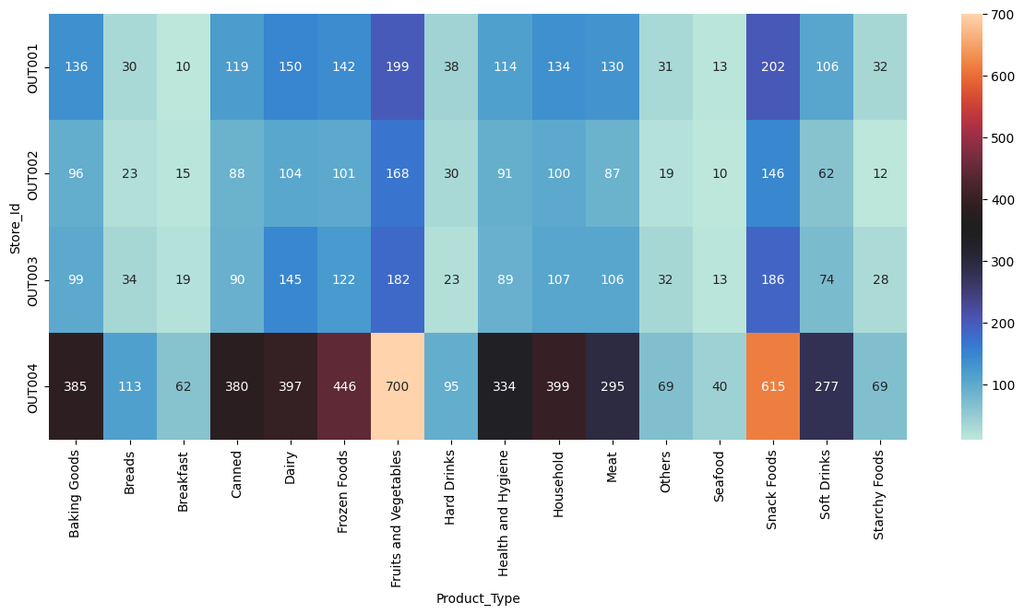

```python
# Visualize this
plt.figure(figsize=(15, 6))
sns.heatmap(pd.crosstab(data.Store_Id, data.Product_Type),
            annot = True,
            cmap = 'icefire',
            fmt = 'g')
plt.show()
```

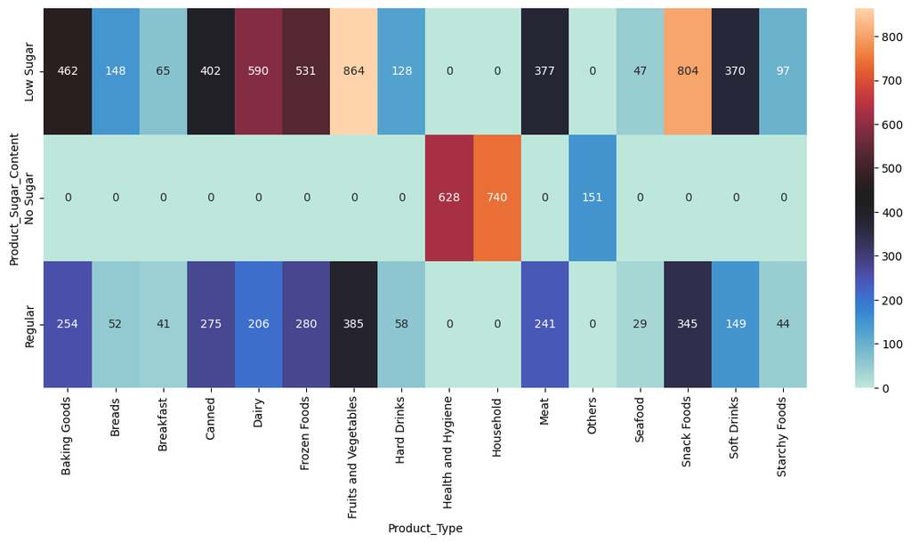

```python
plt.figure(figsize=(15, 6))
sns.heatmap(pd.crosstab(data.Product_Sugar_Content, data.Product_Type),
            annot = True,
            cmap = 'icefire',
            fmt = 'g')
plt.show()
```

# **Data Preprocessing**

Let's convert the Store_Established_Year nto something more meaningful and easier to use by the modle. So ley's ttransform that in store age.

```python
# Store Age
# Check if 'Store_Established_Year' exists in the DataFrame
if 'Store_Establishment_Year' in data.columns:
    data['Store_Age'] = 2024 - data['Store_Establishment_Year']
else:
    print("'Store_Establishment_Year' column not found in the DataFrame.")

# We no longer need the Store_Establishment_Year column, so let's drop it
data.drop('Store_Establishment_Year', axis=1, inplace=True)
```

There are currently 16 different product types, let's categorize those so we can reduce the number of dimensions. There are a number of ways we can do this, for this example lets simplify things into two categories, persihable and non-perishable.

```python
# Find the unique pproduct types  that exist in the data frame
#print(data['Product_Type'].unique())

# Or we cn do the fllowing (which may be easier to read)
data['Product_Type'].value_counts().index.to_list()
```

```
['Fruits and Vegetables',
 'Snack Foods',
 'Frozen Foods',
 'Dairy',
 'Household',
 'Baking Goods',
 'Canned',
 'Health and Hygiene',
 'Meat',
 'Soft Drinks',
 'Breads',
 'Hard Drinks',
 'Others',
 'Starchy Foods',
 'Breakfast',
 'Seafood']
```

```python
# Create a list of perishible items
perishables = [
              "Dairy",
              "Meat",
              "Fruits and Vegetables",
              "Breakfast",
              "Breads",
              "Seafood"
              ]

# Define a function to substitute the new categories for the origals based on our list
def change(x):
    if x in perishables:
        return "Perishables"
    else:
        return "Non Perishables"

# Intsantiate the function to preview the changes
data.Product_Type.apply(change)
```

|  | Product_Type |
| --- | --- |
| 0 | Non Perishables |
| 1 | Perishables |
| 2 | Non Perishables |
| 3 | Non Perishables |
| 4 | Non Perishables |
| ... | ... |
| 8758 | Non Perishables |
| 8759 | Non Perishables |
| 8760 | Non Perishables |
| 8761 | Non Perishables |
| 8762 | Non Perishables |

8763 rows × 1 columns

**dtype:** object

```python
# Perform the transformation by appending a new column to the end of the data frame
change1 = []
for i in range(0, len(data)):
    if data.Product_Type[i] in perishables:
        change1.append("Perishables")
    else:
        change1.append("Non Perishables")

data["Product_Type_Categories"] = change1

# We can now drop the Product_Type column
data.drop('Product_Type', axis=1, inplace=True)

# Check the transformation
data.head()
```

|  | Product_Id | Product_Weight | Product_Sugar_Content | Product_Allocated_Area | Product_MRP | Store_Id | Store_Size | Store_Location_City_Type | Store_Type | Product_Store_Sales_Total | Store_Age | Product_Type_Categories |
| --- | --- | --- | --- | --- | --- | --- | --- | --- | --- | --- | --- | --- |
| 0 | FD | 12.66 | Low Sugar | 0.027 | 117.08 | OUT004 | Medium | Tier 2 | Supermarket Type2 | 2842.40 | 15 | Non Perishables |
| 1 | FD | 16.54 | Low Sugar | 0.144 | 171.43 | OUT003 | Medium | Tier 1 | Departmental Store | 4830.02 | 25 | Perishables |
| 2 | FD | 14.28 | Regular | 0.031 | 162.08 | OUT001 | High | Tier 2 | Supermarket Type1 | 4130.16 | 37 | Non Perishables |
| 3 | FD | 12.10 | Low Sugar | 0.112 | 186.31 | OUT001 | High | Tier 2 | Supermarket Type1 | 4132.18 | 37 | Non Perishables |
| 4 | NC | 9.57 | No Sugar | 0.010 | 123.67 | OUT002 | Small | Tier 3 | Food Mart | 2279.36 | 26 | Non Perishables |

# **Outlier Checks for Numercial Features**

We need to check for. and take care of any outliers that will throw off our prediction calculation.

```python
# Outlier detection using boxplot

#numeric_columns = data.select_dtypes(include=np.number).columns.tolist()
#numeric_columns.remove("Store_Establishment_Year")
#numeric_columns.remove("Store_Age_Years")


numeric_columns = data.select_dtypes(include=np.number).columns.tolist()
numeric_columns
```

```
['Product_Weight',
 'Product_Allocated_Area',
 'Product_MRP',
 'Product_Store_Sales_Total',
 'Store_Age']
```

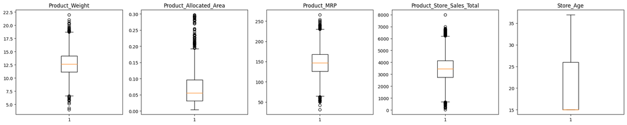

```python
plt.figure(figsize = (20, 15))

for i, variable in enumerate(numeric_columns):
    plt.subplot(4, 5, i + 1)
    plt.boxplot(data[variable], whis = 1.5)
    plt.tight_layout()
    plt.title(variable)

plt.show()
```

**Observations:**

- The data contains many outlies, however, all are explanable
- We will not be treat them as non are out of the ordinary.

# **Data Preparation for Modeling**

We need to encode categorical data using one-hot encoding

```python
# Determine the types of features present in the data frame
data.dtypes.value_counts()
```

|  | count |
| --- | --- |
| object | 7 |
| float64 | 4 |
| int64 | 1 |

**dtype:** int64

```python
data.select_dtypes(include='object').columns.to_list()
```

```
['Product_Id',
 'Product_Sugar_Content',
 'Store_Id',
 'Store_Size',
 'Store_Location_City_Type',
 'Store_Type',
 'Product_Type_Categories']
```

```python
# Perform OHE
data_OHE = pd.get_dummies(
                         data,
                         columns = data.select_dtypes(include='object').columns,
                         drop_first=True
                         )

data_OHE.head()
```

|  | Product_Weight | Product_Allocated_Area | Product_MRP | Product_Store_Sales_Total | Store_Age | Product_Id_FD | Product_Id_NC | Product_Sugar_Content_No Sugar | Product_Sugar_Content_Regular | Store_Id_OUT002 | Store_Id_OUT003 | Store_Id_OUT004 | Store_Size_Medium | Store_Size_Small | Store_Location_City_Type_Tier 2 | Store_Location_City_Type_Tier 3 | Store_Type_Food Mart | Store_Type_Supermarket Type1 | Store_Type_Supermarket Type2 | Product_Type_Categories_Perishables |
| --- | --- | --- | --- | --- | --- | --- | --- | --- | --- | --- | --- | --- | --- | --- | --- | --- | --- | --- | --- | --- |
| 0 | 12.66 | 0.027 | 117.08 | 2842.40 | 15 | True | False | False | False | False | False | True | True | False | True | False | False | False | True | False |
| 1 | 16.54 | 0.144 | 171.43 | 4830.02 | 25 | True | False | False | False | False | True | False | True | False | False | False | False | False | False | True |
| 2 | 14.28 | 0.031 | 162.08 | 4130.16 | 37 | True | False | False | True | False | False | False | False | False | True | False | False | True | False | False |
| 3 | 12.10 | 0.112 | 186.31 | 4132.18 | 37 | True | False | False | False | False | False | False | False | False | True | False | False | True | False | False |
| 4 | 9.57 | 0.010 | 123.67 | 2279.36 | 26 | False | True | True | False | True | False | False | False | True | False | True | True | False | False | False |

```python
x = data_OHE.drop('Product_Store_Sales_Total', axis = 1)  # These are the features
y = data_OHE['Product_Store_Sales_Total']                 # This is the target
```

```python
# Let's make sure everything looks as it should
x.shape, y.shape
```

```
((8763, 19), (8763,))
```

```python
# Lets use the stats models library ( we could also use sklearn)
# Create a bias variable and pre-pend that onto the data frame
x = sm.add_constant(x)

x.head(5)
```

|  | const | Product_Weight | Product_Allocated_Area | Product_MRP | Store_Age | Product_Id_FD | Product_Id_NC | Product_Sugar_Content_No Sugar | Product_Sugar_Content_Regular | Store_Id_OUT002 | Store_Id_OUT003 | Store_Id_OUT004 | Store_Size_Medium | Store_Size_Small | Store_Location_City_Type_Tier 2 | Store_Location_City_Type_Tier 3 | Store_Type_Food Mart | Store_Type_Supermarket Type1 | Store_Type_Supermarket Type2 | Product_Type_Categories_Perishables |
| --- | --- | --- | --- | --- | --- | --- | --- | --- | --- | --- | --- | --- | --- | --- | --- | --- | --- | --- | --- | --- |
| 0 | 1.0 | 12.66 | 0.027 | 117.08 | 15 | True | False | False | False | False | False | True | True | False | True | False | False | False | True | False |
| 1 | 1.0 | 16.54 | 0.144 | 171.43 | 25 | True | False | False | False | False | True | False | True | False | False | False | False | False | False | True |
| 2 | 1.0 | 14.28 | 0.031 | 162.08 | 37 | True | False | False | True | False | False | False | False | False | True | False | False | True | False | False |
| 3 | 1.0 | 12.10 | 0.112 | 186.31 | 37 | True | False | False | False | False | False | False | False | False | True | False | False | True | False | False |
| 4 | 1.0 | 9.57 | 0.010 | 123.67 | 26 | False | True | True | False | True | False | False | False | True | False | True | True | False | False | False |

# **Split Data**

```python
x_train, x_test, y_train, y_test = train_test_split(x, y, test_size = 0.3, random_state = 1)
```

```python
x_train.shape, x_test.shape, y_train.shape, y_test.shape
```

```
((6134, 20), (2629, 20), (6134,), (2629,))
```

# **Model Training**

### **Step One: Multicollinearity Analysis**

- We will use the Variance Inflation Factor (VIF), to check if there is multicollinearity in the data.
- Features having a VIF score > 5 will be dropped/treated till all the features have a VIF score < 5

  Note: It is quite likekly that the VIF score for the categorical values we performed OHE On Hot Encoding) on will be high, we can safely ignore that for those features.

```python
# We need to convert the data type of the T/F data to 1/0 for the actual regression
x_train1 = x_train.astype(float)
y_train1 = y_train.astype(float)

# We need to do the same thing for the test data
x_test1 = x_test.astype(float)
y_test1 = y_test.astype(float)
```

```python
# To see how this works you can compute it in the following way, for a single column
variance_inflation_factor(x_train1.values, 0)
```

```
0.0
```

```python
# Create an empty datafram
VIF_df = pd.DataFrame()

VIF_df['Features'] = x_train1.columns
VIF_df['VIF'] = [variance_inflation_factor(x_train1.values, i) for i in range(x_train1.shape[1])]
VIF_df
```

|  | Features | VIF |
| --- | --- | --- |
| 0 | const | 0.000000 |
| 1 | Product_Weight | 1.752928 |
| 2 | Product_Allocated_Area | 1.001184 |
| 3 | Product_MRP | 1.885058 |
| 4 | Store_Age | inf |
| 5 | Product_Id_FD | 2.774371 |
| 6 | Product_Id_NC | inf |
| 7 | Product_Sugar_Content_No Sugar | inf |
| 8 | Product_Sugar_Content_Regular | 1.088506 |
| 9 | Store_Id_OUT002 | inf |
| 10 | Store_Id_OUT003 | inf |
| 11 | Store_Id_OUT004 | inf |
| 12 | Store_Size_Medium | inf |
| 13 | Store_Size_Small | inf |
| 14 | Store_Location_City_Type_Tier 2 | inf |
| 15 | Store_Location_City_Type_Tier 3 | inf |
| 16 | Store_Type_Food Mart | inf |
| 17 | Store_Type_Supermarket Type1 | inf |
| 18 | Store_Type_Supermarket Type2 | inf |
| 19 | Product_Type_Categories_Perishables | 1.217690 |

Note: the VIF of the calculated Store_Age column if inf, meaning that the information contained in the column can be exactly created by informationin other columns, we will need to drop that column.

```python
x_train.drop('Store_Age', axis = 1, inplace = True)

# We need to remember to do the same thin in the testing data set as well
x_test.drop('Store_Age', axis = 1, inplace = True)
```

```python
# Recompute the VIF
# Create an empty datafram
VIF_df = pd.DataFrame()

VIF_df['Features'] = x_train1.columns
VIF_df['VIF'] = [variance_inflation_factor(x_train1.values, i) for i in range(x_train1.shape[1])]
VIF_df
```

|  | Features | VIF |
| --- | --- | --- |
| 0 | const | 0.000000 |
| 1 | Product_Weight | 1.752928 |
| 2 | Product_Allocated_Area | 1.001184 |
| 3 | Product_MRP | 1.885058 |
| 4 | Store_Age | inf |
| 5 | Product_Id_FD | 2.774371 |
| 6 | Product_Id_NC | inf |
| 7 | Product_Sugar_Content_No Sugar | inf |
| 8 | Product_Sugar_Content_Regular | 1.088506 |
| 9 | Store_Id_OUT002 | inf |
| 10 | Store_Id_OUT003 | inf |
| 11 | Store_Id_OUT004 | inf |
| 12 | Store_Size_Medium | inf |
| 13 | Store_Size_Small | inf |
| 14 | Store_Location_City_Type_Tier 2 | inf |
| 15 | Store_Location_City_Type_Tier 3 | inf |
| 16 | Store_Type_Food Mart | inf |
| 17 | Store_Type_Supermarket Type1 | inf |
| 18 | Store_Type_Supermarket Type2 | inf |
| 19 | Product_Type_Categories_Perishables | 1.217690 |

# **Building Models**

Let's create a function to calculate the performance metrics for our regression model so that we don't need to use the same code repeatedly.

```python
model = sm.OLS(y_train1, x_train1).fit()
model.summary()
```

OLS Regression Results

| Dep. Variable: | Product_Store_Sales_Total | R-squared: | 0.824 |
| --- | --- | --- | --- |
| Model: | OLS | Adj. R-squared: | 0.823 |
| Method: | Least Squares | F-statistic: | 2860. |
| Date: | Wed, 04 Sep 2024 | Prob (F-statistic): | 0.00 |
| Time: | 21:04:47 | Log-Likelihood: | -46132. |
| No. Observations: | 6134 | AIC: | 9.229e+04 |
| Df Residuals: | 6123 | BIC: | 9.236e+04 |
| Df Model: | 10 |  |  |
| Covariance Type: | nonrobust |  |  |

|  | coef | std err | t | P>\|t\| | [0.025 | 0.975] |
| --- | --- | --- | --- | --- | --- | --- |
| const | -58.4335 | 6.034 | -9.684 | 0.000 | -70.262 | -46.605 |
| Product_Weight | 135.0943 | 3.436 | 39.318 | 0.000 | 128.359 | 141.830 |
| Product_Allocated_Area | -139.5679 | 118.876 | -1.174 | 0.240 | -372.608 | 93.472 |
| Product_MRP | 12.8696 | 0.254 | 50.702 | 0.000 | 12.372 | 13.367 |
| Store_Age | 5.0845 | 1.693 | 3.003 | 0.003 | 1.766 | 8.403 |
| Product_Id_FD | 0.3932 | 21.936 | 0.018 | 0.986 | -42.609 | 43.396 |
| Product_Id_NC | 16.0039 | 12.324 | 1.299 | 0.194 | -8.155 | 40.163 |
| Product_Sugar_Content_No Sugar | 16.0039 | 12.324 | 1.299 | 0.194 | -8.155 | 40.163 |
| Product_Sugar_Content_Regular | 30.8608 | 13.284 | 2.323 | 0.020 | 4.819 | 56.902 |
| Store_Id_OUT002 | -261.6689 | 4.242 | -61.689 | 0.000 | -269.984 | -253.354 |
| Store_Id_OUT003 | 323.1208 | 9.566 | 33.779 | 0.000 | 304.368 | 341.873 |
| Store_Id_OUT004 | -143.9189 | 6.803 | -21.155 | 0.000 | -157.255 | -130.583 |
| Store_Size_Medium | 179.2019 | 14.093 | 12.716 | 0.000 | 151.575 | 206.828 |
| Store_Size_Small | -261.6689 | 4.242 | -61.689 | 0.000 | -269.984 | -253.354 |
| Store_Location_City_Type_Tier 2 | -119.8854 | 5.097 | -23.523 | 0.000 | -129.877 | -109.894 |
| Store_Location_City_Type_Tier 3 | -261.6689 | 4.242 | -61.689 | 0.000 | -269.984 | -253.354 |
| Store_Type_Food Mart | -261.6689 | 4.242 | -61.689 | 0.000 | -269.984 | -253.354 |
| Store_Type_Supermarket Type1 | 24.0335 | 7.601 | 3.162 | 0.002 | 9.133 | 38.934 |
| Store_Type_Supermarket Type2 | -143.9189 | 6.803 | -21.155 | 0.000 | -157.255 | -130.583 |
| Product_Type_Categories_Perishables | 7.7111 | 13.233 | 0.583 | 0.560 | -18.231 | 33.653 |

| Omnibus: | 1745.262 | Durbin-Watson: | 1.987 |
| --- | --- | --- | --- |
| Prob(Omnibus): | 0.000 | Jarque-Bera (JB): | 46497.082 |
| Skew: | 0.775 | Prob(JB): | 0.00 |
| Kurtosis: | 16.399 | Cond. No. | 6.36e+34 |

Notes:  
[1] Standard Errors assume that the covariance matrix of the errors is correctly specified.  
[2] The smallest eigenvalue is 3.51e-62. This might indicate that there are  
strong multicollinearity problems or that the design matrix is singular.

**A concern: OUT004 sells more than any other store, in some cases outselling all other stores combined, but the coef would indicate it has a negative impact on sales?**

## **Predictions**

```python
y_hat = model.predict(x_train1)
```

```python
from sklearn.metrics import r2_score, mean_absolute_percentage_error, mean_absolute_error, mean_squared_error
```

```python
# Let's examine the r2 score
r2_score(y_train1, y_hat)
```

```
0.8236738620512217
```

```python
# mean_squared_error
mean_squared_error(y_train1, y_hat)
```

```
199511.99287139165
```

```python
# Model Performance on test and train data
def model_evaluation(model, x, y):  # Changed function parameters to accept x and y directly
  y_hat = model.predict(x)          # Use the correct x for prediction

  rmse = np.sqrt(mean_squared_error(y, y_hat))
  mae  = mean_absolute_error(y, y_hat)
  mape = mean_absolute_percentage_error(y, y_hat)
  r2   = r2_score(y, y_hat)

  return pd.DataFrame({'RMSE': [rmse], 'MAE': [mae], 'MAPE': [mape], 'R2': [r2]})

# Perform the regression on the training data
train = model_evaluation(model, x_train1, y_train1)

# Perform the regression on the test data
test = model_evaluation(model, x_test1, y_test1)

# Label rows
train.index = ['Train']
test.index = ['Test']

# Concatenate the result
pd.concat([train, test], axis = 0)
```

|  | RMSE | MAE | MAPE | R2 |
| --- | --- | --- | --- | --- |
| Train | 446.667654 | 262.110666 | 0.098564 | 0.823674 |
| Test | 446.685287 | 266.690587 | 0.104608 | 0.825641 |

### **Observations:**

**RMSE** and **MAE** values are relatively low, indicating that your model’s predictions are close to the actual values.

**R2** is around 0.824, meaning your model explains about 82.4% of the variance in the data, which is generally considered a good fit.

These results suggest that your model is performing well.

This may be able to be improved by dropping some of the insignificat (high p value) columns or adding complexity back in by adding the Product_Types back in.

## There is an opportunity to fine tune the model here - not completed

### **Observations:**

The model performs slightly worse with the test data, but not to a great extent.

We could go through and take a closer look at any functions with a high p value (p >= 0.05) and re-train the model and run the regression.

Check model with zero mean (not sure what that means)

```python
# Redidue of the model
model.resid

# which is this calculation#
y_train1 - model.predict(x_train1)
```

|  | 0 |
| --- | --- |
| 910 | -157.136399 |
| 7022 | -27.190868 |
| 8056 | 359.346837 |
| 2939 | 0.843308 |
| 68 | 126.494755 |
| ... | ... |
| 2895 | 165.265382 |
| 7813 | -240.653427 |
| 905 | 200.238129 |
| 5192 | 20.060083 |
| 235 | -106.886905 |

6134 rows × 1 columns

**dtype:** float64

### **Checking the below linear regression assumptions**

1. **Mean of residuals should be 0**
2. **No Heteroscedasticity**
3. **Linearity of variables**
4. **Normality of error terms**

### **1. Check for mean residuals**

This should be as close to zero as possible

```python
np.mean(model.resid)
```

```
-1.438585163756384e-11
```

### **2. Check for homoscedasticity**

- Homoscedasticity - If the residuals are symmetrically distributed across the regression line, then the data is said to be homoscedastic.
- Heteroscedasticity- - If the residuals are not symmetrically distributed across the regression line, then the data is said to be heteroscedastic. In this case, the residuals can form a funnel shape or any other non-symmetrical shape.
- We'll use `Goldfeldquandt Test` to test the following hypothesis with alpha = 0.05:
  - Null hypothesis: Residuals are homoscedastic
  - Alternate hypothesis: Residuals have heteroscedastic

```python
result = sms.het_goldfeldquandt(y_train1, x_train1)
result
# The second value is nothing but the p-value
```

```
(0.9838049659112555, 0.6741005762249113, 'increasing')
```

**Observation:**

- Since p-value > 0.05, we cannot reject the Null Hypothesis that the residuals are homoscedastic and the corresponding assumption is satisfied.

### **3. Linearity of variables**

It states that the predictor variables must have a linear relation with the dependent variable.

To test the assumption, we'll plot residuals and the fitted values on a plot and ensure that residuals do not form a strong pattern. They should be randomly and uniformly scattered on the x-axis.

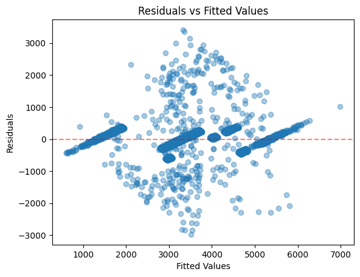

```python
# Plot residual vs fitted values -  we need to not see a pattern here
model.fittedvalues    # the same as model.predict(x_train1)

# create a scatterplot
plt.scatter(model.fittedvalues, model.resid, alpha = 0.4)
plt.axhline(y = 0, color = 'r', linestyle = '--', alpha = 0.5)
plt.title('Residuals vs Fitted Values')
plt.xlabel('Fitted Values')
plt.ylabel('Residuals')
plt.show()
```

**Observation:**

### **4. Normality of error terms**

The residuals should be normally distributed.

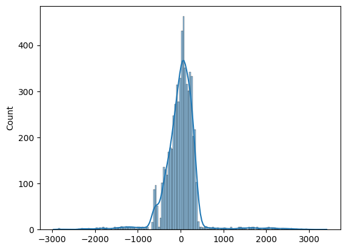

```python
# Plot histogram of residuals
sns.histplot(model.resid, kde = True)
```

This looks like a normal distibution, but let's chck one more thing to be sure.

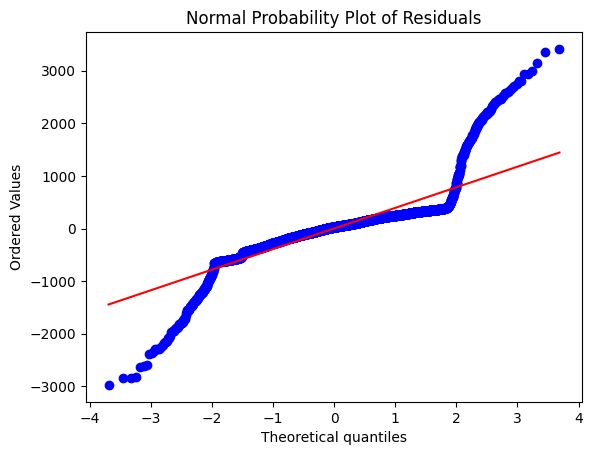

```python
stats.probplot(model.resid, dist = 'norm', plot = pylab)
plt.title('Normal Probability Plot of Residuals')
plt.show()
```

**Observation:**

### **Apply cross validation to improve the model and evaluate it using different evaluation metrics**

```python
model2 = LinearRegression()

mae_ = cross_val_score(model2, x_train1, y_train1, cv = 10, scoring = 'neg_mean_absolute_percentage_error')  # This gives percenatge error for different folds where cv is the number of folds
```

```python
# Get the mean of mae_
np.mean(-mae_)
```

```
0.09884834456107033
```

```python
# Std deviation
np.std(-mae_)
```

```
0.009025108770564186
```

```python
# Assume a normal distibution
np.mean(-mae_) - 3 * np.std(-mae_), np.mean(-mae_) + 3 * np.std(-mae_)  # range at which 99.7% of the time the error stays withing this range
```

```
(0.07177301824937778, 0.1259236708727629)
```

```python
# Do the same on the test data set - even though this doesnt make a lot of sense given the model is now being trained on a very small data set
np.mean(cross_val_score(model2, x_test1, y_test1, cv = 10, scoring = 'neg_mean_absolute_percentage_error'))
```

```
-0.09818012800305127
```

## **Actionable Insights and Business Recommendations**

**Additional information that can be collected to gain better insights -**

- Customers' details like age and gender can be incorporated in this model so that the company gets to know their target audience well and can build their sales strategies according to that.
- The company should also keep a watch for the number of festive occasions present in a quarter so that they can strategize their inventory accordingly.

```python
# Convert notebook to html
!jupyter nbconvert --to html "/content/drive/MyDrive/MIT - Data Sciences/Colab Notebooks/Week Four - Regression and Prediction/Guided Project/SuperKart Sales Prediction.ipynb"
```